# Risk Factor Analysis

## Outcome Variable

**Outcome Variable:** wasted

## Predictor Variables

**Intervention Variable:** exclfeed6

**Adjustment Set:**

unadjusted

## Stratifying Variables

The analysis was stratified on these variable(s):

- agecat
- studyid
- country

## Data Summary

| agecat | studyid | country | exclfeed6 | wasted | n_cell | n |
| --- | --- | --- | --- | --- | --- | --- |
| Birth | CMC-V-BCS-2002 | INDIA | 1 | 0 | 7 | 7 |
| Birth | CMC-V-BCS-2002 | INDIA | 1 | 1 | 0 | 7 |
| Birth | CMC-V-BCS-2002 | INDIA | 0 | 0 | 0 | 7 |
| Birth | CMC-V-BCS-2002 | INDIA | 0 | 1 | 0 | 7 |
| Birth | EE | PAKISTAN | 1 | 0 | 20 | 28 |
| Birth | EE | PAKISTAN | 1 | 1 | 4 | 28 |
| Birth | EE | PAKISTAN | 0 | 0 | 3 | 28 |
| Birth | EE | PAKISTAN | 0 | 1 | 1 | 28 |
| Birth | GMS-Nepal | NEPAL | 1 | 0 | 309 | 522 |
| Birth | GMS-Nepal | NEPAL | 1 | 1 | 81 | 522 |
| Birth | GMS-Nepal | NEPAL | 0 | 0 | 111 | 522 |
| Birth | GMS-Nepal | NEPAL | 0 | 1 | 21 | 522 |
| Birth | IRC | INDIA | 1 | 0 | 0 | 12 |
| Birth | IRC | INDIA | 1 | 1 | 0 | 12 |
| Birth | IRC | INDIA | 0 | 0 | 8 | 12 |
| Birth | IRC | INDIA | 0 | 1 | 4 | 12 |
| Birth | JiVitA-3 | BANGLADESH | 1 | 0 | 7428 | 10744 |
| Birth | JiVitA-3 | BANGLADESH | 1 | 1 | 953 | 10744 |
| Birth | JiVitA-3 | BANGLADESH | 0 | 0 | 2121 | 10744 |
| Birth | JiVitA-3 | BANGLADESH | 0 | 1 | 242 | 10744 |
| Birth | JiVitA-4 | BANGLADESH | 1 | 0 | 1623 | 2224 |
| Birth | JiVitA-4 | BANGLADESH | 1 | 1 | 176 | 2224 |
| Birth | JiVitA-4 | BANGLADESH | 0 | 0 | 378 | 2224 |
| Birth | JiVitA-4 | BANGLADESH | 0 | 1 | 47 | 2224 |
| Birth | Keneba | GAMBIA | 1 | 0 | 351 | 1327 |
| Birth | Keneba | GAMBIA | 1 | 1 | 99 | 1327 |
| Birth | Keneba | GAMBIA | 0 | 0 | 645 | 1327 |
| Birth | Keneba | GAMBIA | 0 | 1 | 232 | 1327 |
| Birth | MAL-ED | BANGLADESH | 1 | 0 | 25 | 194 |
| Birth | MAL-ED | BANGLADESH | 1 | 1 | 4 | 194 |

[output cut: 170 more lines]

The following strata were considered:

- agecat: 24 months, studyid: CMC-V-BCS-2002, country: INDIA
- agecat: 24 months, studyid: EE, country: PAKISTAN
- agecat: 24 months, studyid: GMS-Nepal, country: NEPAL
- agecat: 24 months, studyid: IRC, country: INDIA
- agecat: 24 months, studyid: JiVitA-3, country: BANGLADESH
- agecat: 24 months, studyid: JiVitA-4, country: BANGLADESH
- agecat: 24 months, studyid: Keneba, country: GAMBIA
- agecat: 24 months, studyid: LCNI-5, country: MALAWI
- agecat: 24 months, studyid: MAL-ED, country: BANGLADESH
- agecat: 24 months, studyid: MAL-ED, country: BRAZIL
- agecat: 24 months, studyid: MAL-ED, country: INDIA
- agecat: 24 months, studyid: MAL-ED, country: NEPAL
- agecat: 24 months, studyid: MAL-ED, country: PERU
- agecat: 24 months, studyid: MAL-ED, country: SOUTH AFRICA
- agecat: 24 months, studyid: MAL-ED, country: TANZANIA, UNITED REPUBLIC OF
- agecat: 24 months, studyid: PROVIDE, country: BANGLADESH
- agecat: 6 months, studyid: CMC-V-BCS-2002, country: INDIA
- agecat: 6 months, studyid: EE, country: PAKISTAN
- agecat: 6 months, studyid: GMS-Nepal, country: NEPAL
- agecat: 6 months, studyid: IRC, country: INDIA
- agecat: 6 months, studyid: JiVitA-3, country: BANGLADESH
- agecat: 6 months, studyid: JiVitA-4, country: BANGLADESH
- agecat: 6 months, studyid: Keneba, country: GAMBIA
- agecat: 6 months, studyid: LCNI-5, country: MALAWI
- agecat: 6 months, studyid: MAL-ED, country: BANGLADESH
- agecat: 6 months, studyid: MAL-ED, country: BRAZIL
- agecat: 6 months, studyid: MAL-ED, country: INDIA
- agecat: 6 months, studyid: MAL-ED, country: NEPAL
- agecat: 6 months, studyid: MAL-ED, country: PERU
- agecat: 6 months, studyid: MAL-ED, country: SOUTH AFRICA
- agecat: 6 months, studyid: MAL-ED, country: TANZANIA, UNITED REPUBLIC OF
- agecat: 6 months, studyid: PROVIDE, country: BANGLADESH
- agecat: 6 months, studyid: SAS-CompFeed, country: INDIA
- agecat: 6 months, studyid: SAS-FoodSuppl, country: INDIA
- agecat: Birth, studyid: CMC-V-BCS-2002, country: INDIA
- agecat: Birth, studyid: EE, country: PAKISTAN
- agecat: Birth, studyid: GMS-Nepal, country: NEPAL
- agecat: Birth, studyid: IRC, country: INDIA
- agecat: Birth, studyid: JiVitA-3, country: BANGLADESH
- agecat: Birth, studyid: JiVitA-4, country: BANGLADESH
- agecat: Birth, studyid: Keneba, country: GAMBIA
- agecat: Birth, studyid: MAL-ED, country: BANGLADESH
- agecat: Birth, studyid: MAL-ED, country: BRAZIL
- agecat: Birth, studyid: MAL-ED, country: INDIA
- agecat: Birth, studyid: MAL-ED, country: NEPAL
- agecat: Birth, studyid: MAL-ED, country: PERU
- agecat: Birth, studyid: MAL-ED, country: SOUTH AFRICA
- agecat: Birth, studyid: MAL-ED, country: TANZANIA, UNITED REPUBLIC OF
- agecat: Birth, studyid: PROVIDE, country: BANGLADESH
- agecat: Birth, studyid: SAS-CompFeed, country: INDIA

### Dropped Strata

Some strata were dropped due to rare outcomes:

- agecat: Birth, studyid: CMC-V-BCS-2002, country: INDIA
- agecat: Birth, studyid: EE, country: PAKISTAN
- agecat: Birth, studyid: IRC, country: INDIA
- agecat: Birth, studyid: MAL-ED, country: BANGLADESH
- agecat: Birth, studyid: MAL-ED, country: BRAZIL
- agecat: Birth, studyid: MAL-ED, country: INDIA
- agecat: Birth, studyid: MAL-ED, country: NEPAL
- agecat: Birth, studyid: MAL-ED, country: PERU
- agecat: Birth, studyid: MAL-ED, country: SOUTH AFRICA
- agecat: Birth, studyid: MAL-ED, country: TANZANIA, UNITED REPUBLIC OF
- agecat: Birth, studyid: SAS-CompFeed, country: INDIA
- agecat: 6 months, studyid: CMC-V-BCS-2002, country: INDIA
- agecat: 6 months, studyid: EE, country: PAKISTAN
- agecat: 6 months, studyid: IRC, country: INDIA
- agecat: 6 months, studyid: LCNI-5, country: MALAWI
- agecat: 6 months, studyid: MAL-ED, country: BANGLADESH
- agecat: 6 months, studyid: MAL-ED, country: BRAZIL
- agecat: 6 months, studyid: MAL-ED, country: INDIA
- agecat: 6 months, studyid: MAL-ED, country: NEPAL
- agecat: 6 months, studyid: MAL-ED, country: PERU
- agecat: 6 months, studyid: MAL-ED, country: SOUTH AFRICA
- agecat: 6 months, studyid: MAL-ED, country: TANZANIA, UNITED REPUBLIC OF
- agecat: 6 months, studyid: PROVIDE, country: BANGLADESH
- agecat: 6 months, studyid: SAS-CompFeed, country: INDIA
- agecat: 6 months, studyid: SAS-FoodSuppl, country: INDIA
- agecat: 24 months, studyid: CMC-V-BCS-2002, country: INDIA
- agecat: 24 months, studyid: EE, country: PAKISTAN
- agecat: 24 months, studyid: IRC, country: INDIA
- agecat: 24 months, studyid: LCNI-5, country: MALAWI
- agecat: 24 months, studyid: MAL-ED, country: BANGLADESH
- agecat: 24 months, studyid: MAL-ED, country: BRAZIL
- agecat: 24 months, studyid: MAL-ED, country: INDIA
- agecat: 24 months, studyid: MAL-ED, country: NEPAL
- agecat: 24 months, studyid: MAL-ED, country: PERU
- agecat: 24 months, studyid: MAL-ED, country: SOUTH AFRICA
- agecat: 24 months, studyid: MAL-ED, country: TANZANIA, UNITED REPUBLIC OF

## Methods Detail

We’re interested in the causal parameters $E[Y_a]$ for all values of $a \in \mathcal{A}$. These parameters represent the mean outcome if, possibly contrary to fact, we intervened to set all units to have $A=a$. Under the randomization and positivity assumptions, these are identified by the statistical parameters $\psi_a=E_W[E_{Y|A,W}(Y|A=a,W)]$. In addition, we’re interested in the mean of $Y$, $E[Y]$ under no intervention (the observed mean). We will estimate these parameters by using SuperLearner to fit the relevant likelihood factors – $E_{Y|A,W}(Y|A=a,W)$ and $p(A=a|W)$, and then updating our likelihood fit using a joint TMLE.

For unadjusted analyses ($W=\{\}$), initial likelihoods were estimated using Lrnr_glm to estimate the simple $E(Y|A)$ and Lrnr_mean to estimate $p(A)$. For adjusted analyses, a small library containing Lrnr_glmnet, Lrnr_xgboost, and Lrnr_mean was used.

Having estimated these parameters, we will then use the delta method to estimate relative risks and attributable risks relative to a prespecified baseline level of $A$.

# Results Detail

## Results Plots

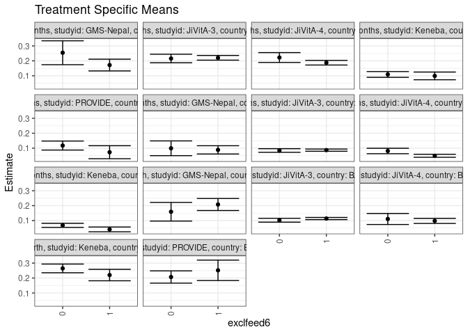

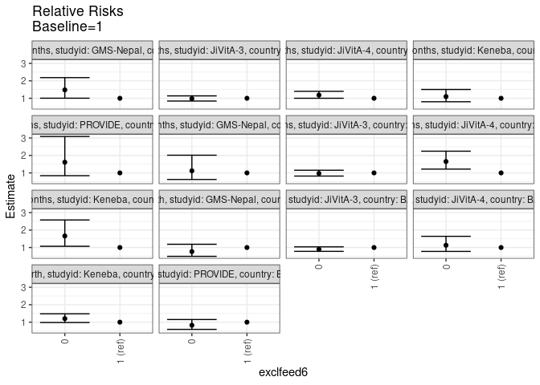

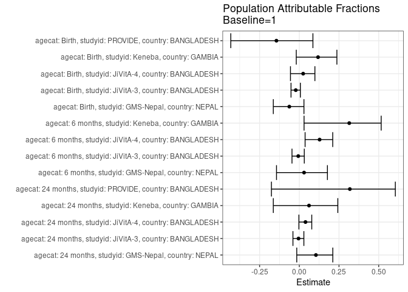

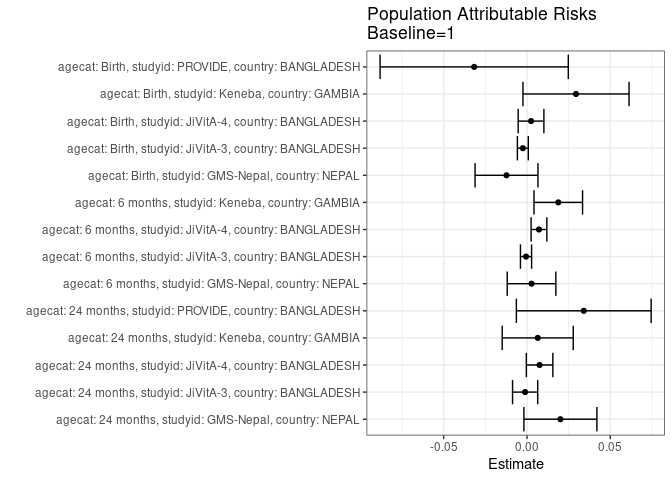

## Results Table

### Parameter: TSM

| agecat | studyid | country | intervention_level | baseline_level | estimate | ci_lower | ci_upper |
| --- | --- | --- | --- | --- | --- | --- | --- |
| Birth | GMS-Nepal | NEPAL | 1 | NA | 0.2076923 | 0.1673938 | 0.2479908 |
| Birth | GMS-Nepal | NEPAL | 0 | NA | 0.1590909 | 0.0966348 | 0.2215470 |
| Birth | JiVitA-3 | BANGLADESH | 1 | NA | 0.1137096 | 0.1064898 | 0.1209293 |
| Birth | JiVitA-3 | BANGLADESH | 0 | NA | 0.1024122 | 0.0894140 | 0.1154104 |
| Birth | JiVitA-4 | BANGLADESH | 1 | NA | 0.0978321 | 0.0808004 | 0.1148639 |
| Birth | JiVitA-4 | BANGLADESH | 0 | NA | 0.1105882 | 0.0736556 | 0.1475209 |
| Birth | Keneba | GAMBIA | 1 | NA | 0.2200000 | 0.1817119 | 0.2582881 |
| Birth | Keneba | GAMBIA | 0 | NA | 0.2645382 | 0.2353346 | 0.2937418 |
| Birth | PROVIDE | BANGLADESH | 1 | NA | 0.2516129 | 0.1832343 | 0.3199915 |
| Birth | PROVIDE | BANGLADESH | 0 | NA | 0.2068966 | 0.1659679 | 0.2478252 |
| 6 months | GMS-Nepal | NEPAL | 1 | NA | 0.0886700 | 0.0609936 | 0.1163463 |
| 6 months | GMS-Nepal | NEPAL | 0 | NA | 0.0992908 | 0.0498844 | 0.1486971 |
| 6 months | JiVitA-3 | BANGLADESH | 1 | NA | 0.0869908 | 0.0796231 | 0.0943585 |
| 6 months | JiVitA-3 | BANGLADESH | 0 | NA | 0.0845070 | 0.0722904 | 0.0967237 |
| 6 months | JiVitA-4 | BANGLADESH | 1 | NA | 0.0491704 | 0.0390057 | 0.0593352 |
| 6 months | JiVitA-4 | BANGLADESH | 0 | NA | 0.0812500 | 0.0630642 | 0.0994358 |
| 6 months | Keneba | GAMBIA | 1 | NA | 0.0409556 | 0.0249051 | 0.0570062 |
| 6 months | Keneba | GAMBIA | 0 | NA | 0.0680787 | 0.0544974 | 0.0816600 |
| 24 months | GMS-Nepal | NEPAL | 1 | NA | 0.1718310 | 0.1325477 | 0.2111143 |
| 24 months | GMS-Nepal | NEPAL | 0 | NA | 0.2543860 | 0.1743541 | 0.3344178 |
| 24 months | JiVitA-3 | BANGLADESH | 1 | NA | 0.2205694 | 0.2048132 | 0.2363256 |
| 24 months | JiVitA-3 | BANGLADESH | 0 | NA | 0.2157534 | 0.1872226 | 0.2442842 |
| 24 months | JiVitA-4 | BANGLADESH | 1 | NA | 0.1876914 | 0.1722260 | 0.2031568 |
| 24 months | JiVitA-4 | BANGLADESH | 0 | NA | 0.2222222 | 0.1891984 | 0.2552460 |
| 24 months | Keneba | GAMBIA | 1 | NA | 0.0992218 | 0.0733681 | 0.1250755 |
| 24 months | Keneba | GAMBIA | 0 | NA | 0.1090000 | 0.0896784 | 0.1283216 |
| 24 months | PROVIDE | BANGLADESH | 1 | NA | 0.0729927 | 0.0293969 | 0.1165885 |
| 24 months | PROVIDE | BANGLADESH | 0 | NA | 0.1176471 | 0.0875846 | 0.1477095 |

### Parameter: E(Y)

| agecat | studyid | country | intervention_level | baseline_level | estimate | ci_lower | ci_upper |
| --- | --- | --- | --- | --- | --- | --- | --- |
| Birth | GMS-Nepal | NEPAL | NA | NA | 0.1954023 | 0.1613549 | 0.2294497 |
| Birth | JiVitA-3 | BANGLADESH | NA | NA | 0.1112249 | 0.1049045 | 0.1175452 |
| Birth | JiVitA-4 | BANGLADESH | NA | NA | 0.1002698 | 0.0846581 | 0.1158815 |
| Birth | Keneba | GAMBIA | NA | NA | 0.2494348 | 0.2261459 | 0.2727237 |
| Birth | PROVIDE | BANGLADESH | NA | NA | 0.2199248 | 0.1846953 | 0.2551543 |
| 6 months | GMS-Nepal | NEPAL | NA | NA | 0.0914077 | 0.0672348 | 0.1155805 |
| 6 months | JiVitA-3 | BANGLADESH | NA | NA | 0.0864198 | 0.0802086 | 0.0926309 |
| 6 months | JiVitA-4 | BANGLADESH | NA | NA | 0.0563743 | 0.0475411 | 0.0652074 |
| 6 months | Keneba | GAMBIA | NA | NA | 0.0597484 | 0.0491105 | 0.0703864 |
| 24 months | GMS-Nepal | NEPAL | NA | NA | 0.1918977 | 0.1562203 | 0.2275751 |
| 24 months | JiVitA-3 | BANGLADESH | NA | NA | 0.2194592 | 0.2057462 | 0.2331723 |
| 24 months | JiVitA-4 | BANGLADESH | NA | NA | 0.1952677 | 0.1809764 | 0.2095589 |
| 24 months | Keneba | GAMBIA | NA | NA | 0.1056803 | 0.0901896 | 0.1211711 |
| 24 months | PROVIDE | BANGLADESH | NA | NA | 0.1070812 | 0.0818727 | 0.1322897 |

### Parameter: RR

| agecat | studyid | country | intervention_level | baseline_level | estimate | ci_lower | ci_upper |
| --- | --- | --- | --- | --- | --- | --- | --- |
| Birth | GMS-Nepal | NEPAL | 1 | 1 | 1.0000000 | 1.0000000 | 1.000000 |
| Birth | GMS-Nepal | NEPAL | 0 | 1 | 0.7659933 | 0.4943584 | 1.186883 |
| Birth | JiVitA-3 | BANGLADESH | 1 | 1 | 1.0000000 | 1.0000000 | 1.000000 |
| Birth | JiVitA-3 | BANGLADESH | 0 | 1 | 0.9006470 | 0.7816416 | 1.037771 |
| Birth | JiVitA-4 | BANGLADESH | 1 | 1 | 1.0000000 | 1.0000000 | 1.000000 |
| Birth | JiVitA-4 | BANGLADESH | 0 | 1 | 1.1303877 | 0.7782405 | 1.641879 |
| Birth | Keneba | GAMBIA | 1 | 1 | 1.0000000 | 1.0000000 | 1.000000 |
| Birth | Keneba | GAMBIA | 0 | 1 | 1.2024464 | 0.9784960 | 1.477653 |
| Birth | PROVIDE | BANGLADESH | 1 | 1 | 1.0000000 | 1.0000000 | 1.000000 |
| Birth | PROVIDE | BANGLADESH | 0 | 1 | 0.8222812 | 0.5875410 | 1.150807 |
| 6 months | GMS-Nepal | NEPAL | 1 | 1 | 1.0000000 | 1.0000000 | 1.000000 |
| 6 months | GMS-Nepal | NEPAL | 0 | 1 | 1.1197794 | 0.6223492 | 2.014794 |
| 6 months | JiVitA-3 | BANGLADESH | 1 | 1 | 1.0000000 | 1.0000000 | 1.000000 |
| 6 months | JiVitA-3 | BANGLADESH | 0 | 1 | 0.9714480 | 0.8187332 | 1.152648 |
| 6 months | JiVitA-4 | BANGLADESH | 1 | 1 | 1.0000000 | 1.0000000 | 1.000000 |
| 6 months | JiVitA-4 | BANGLADESH | 0 | 1 | 1.6524156 | 1.2173657 | 2.242939 |
| 6 months | Keneba | GAMBIA | 1 | 1 | 1.0000000 | 1.0000000 | 1.000000 |
| 6 months | Keneba | GAMBIA | 0 | 1 | 1.6622542 | 1.0708153 | 2.580360 |
| 24 months | GMS-Nepal | NEPAL | 1 | 1 | 1.0000000 | 1.0000000 | 1.000000 |
| 24 months | GMS-Nepal | NEPAL | 0 | 1 | 1.4804429 | 1.0034471 | 2.184182 |
| 24 months | JiVitA-3 | BANGLADESH | 1 | 1 | 1.0000000 | 1.0000000 | 1.000000 |
| 24 months | JiVitA-3 | BANGLADESH | 0 | 1 | 0.9781658 | 0.8409744 | 1.137738 |
| 24 months | JiVitA-4 | BANGLADESH | 1 | 1 | 1.0000000 | 1.0000000 | 1.000000 |
| 24 months | JiVitA-4 | BANGLADESH | 0 | 1 | 1.1839768 | 1.0012224 | 1.400090 |
| 24 months | Keneba | GAMBIA | 1 | 1 | 1.0000000 | 1.0000000 | 1.000000 |
| 24 months | Keneba | GAMBIA | 0 | 1 | 1.0985490 | 0.8015932 | 1.505514 |
| 24 months | PROVIDE | BANGLADESH | 1 | 1 | 1.0000000 | 1.0000000 | 1.000000 |
| 24 months | PROVIDE | BANGLADESH | 0 | 1 | 1.6117647 | 0.8417271 | 3.086256 |

### Parameter: PAR

| agecat | studyid | country | intervention_level | baseline_level | estimate | ci_lower | ci_upper |
| --- | --- | --- | --- | --- | --- | --- | --- |
| Birth | GMS-Nepal | NEPAL | 1 | NA | -0.0122900 | -0.0311731 | 0.0065930 |
| Birth | JiVitA-3 | BANGLADESH | 1 | NA | -0.0024847 | -0.0057560 | 0.0007866 |
| Birth | JiVitA-4 | BANGLADESH | 1 | NA | 0.0024377 | -0.0052771 | 0.0101524 |
| Birth | Keneba | GAMBIA | 1 | NA | 0.0294348 | -0.0024100 | 0.0612797 |
| Birth | PROVIDE | BANGLADESH | 1 | NA | -0.0316881 | -0.0881879 | 0.0248117 |
| 6 months | GMS-Nepal | NEPAL | 1 | NA | 0.0027377 | -0.0118650 | 0.0173404 |
| 6 months | JiVitA-3 | BANGLADESH | 1 | NA | -0.0005710 | -0.0039208 | 0.0027787 |
| 6 months | JiVitA-4 | BANGLADESH | 1 | NA | 0.0072038 | 0.0024820 | 0.0119257 |
| 6 months | Keneba | GAMBIA | 1 | NA | 0.0187928 | 0.0042140 | 0.0333716 |
| 24 months | GMS-Nepal | NEPAL | 1 | NA | 0.0200667 | -0.0018400 | 0.0419733 |
| 24 months | JiVitA-3 | BANGLADESH | 1 | NA | -0.0011101 | -0.0086621 | 0.0064418 |
| 24 months | JiVitA-4 | BANGLADESH | 1 | NA | 0.0075763 | -0.0003790 | 0.0155316 |
| 24 months | Keneba | GAMBIA | 1 | NA | 0.0064585 | -0.0148611 | 0.0277781 |
| 24 months | PROVIDE | BANGLADESH | 1 | NA | 0.0340885 | -0.0063670 | 0.0745439 |

### Parameter: PAF

| agecat | studyid | country | intervention_level | baseline_level | estimate | ci_lower | ci_upper |
| --- | --- | --- | --- | --- | --- | --- | --- |
| Birth | GMS-Nepal | NEPAL | 1 | NA | -0.0628959 | -0.1637323 | 0.0292031 |
| Birth | JiVitA-3 | BANGLADESH | 1 | NA | -0.0223395 | -0.0521601 | 0.0066358 |
| Birth | JiVitA-4 | BANGLADESH | 1 | NA | 0.0243110 | -0.0556208 | 0.0981903 |
| Birth | Keneba | GAMBIA | 1 | NA | 0.1180060 | -0.0191368 | 0.2366939 |
| Birth | PROVIDE | BANGLADESH | 1 | NA | -0.1440860 | -0.4316602 | 0.0857238 |
| 6 months | GMS-Nepal | NEPAL | 1 | NA | 0.0299507 | -0.1435240 | 0.1771091 |
| 6 months | JiVitA-3 | BANGLADESH | 1 | NA | -0.0066078 | -0.0460751 | 0.0313703 |
| 6 months | JiVitA-4 | BANGLADESH | 1 | NA | 0.1277858 | 0.0365011 | 0.2104219 |
| 6 months | Keneba | GAMBIA | 1 | NA | 0.3145321 | 0.0298959 | 0.5156537 |
| 24 months | GMS-Nepal | NEPAL | 1 | NA | 0.1045696 | -0.0161000 | 0.2109088 |
| 24 months | JiVitA-3 | BANGLADESH | 1 | NA | -0.0050585 | -0.0400626 | 0.0287675 |
| 24 months | JiVitA-4 | BANGLADESH | 1 | NA | 0.0387997 | -0.0025496 | 0.0784435 |
| 24 months | Keneba | GAMBIA | 1 | NA | 0.0611138 | -0.1637440 | 0.2425248 |
| 24 months | PROVIDE | BANGLADESH | 1 | NA | 0.3183424 | -0.1756416 | 0.6047629 |